# SARS-CoV-2-specific T cell receptors after disease and vaccination

Maria S. Benitez-Cantos

03/09/2021

# 1 Introduction

This notebook contains the code for the generation of most of the plots of my masters thesis titled "SARS-CoV-2-specific T cell receptors after disease and vaccination". More code and information regarding the generation of the used datasets is available upon request.

# 2 Input data and methods

Required libraries:

```r
library(dplyr)
```

```r
library(tidyr)
library(ggplot2)
library(ggpubr)
library(rstatix)
library(patchwork)
library(ggraph)
library(igraph)
library(parallel)
library(gggenes)
library(factoextra)
```

## 2.1 Metadata

Two sample metadata files are necessary:

- `repertoire_metadata`: contains sample IDs and their respective groups

```r
repertoire_metadata <- readRDS("data/repertoire_metadata.rds")
```

- `adaptive_metadata`: contains sample metadata provided by Adaptive Biotechnologies:

```r
adaptive_metadata <- readRDS("data/adaptive_metadata.rds")
```

## 2.2 Data

- `breadth_depth`: contains spike and non-spike breadth and depth measurements:

```r
breadth_depth <- readRDS("data/breadth_depth.rds")
```

- `metaclono_annotation`: contains information of all the SARS-CoV-2-specific TCRs found in the samples:

```r
metaclono_annotation <- readRDS("data/metaclono_annotation.rds")
```

- `covid_networks`: a list of `igraph` objects that contain all the SARS-CoV-2-specific TCR networks:

```r
covid_networks <- readRDS("data/covid_networks.rds")
```

- `covid_global_metrics`: global network metrics for every SARS-CoV-2-specific TCR network:

```r
covid_global_metrics <- readRDS("data/covid_global_metrics.rds")
```

- `covid_sns_local_metrics`: local network metrics of SARS-CoV-2-specific nodes (TCRs):

```r
covid_sns_local_metrics <- readRDS("data/covid_sns_local_metrics.rds")
```

# 3 Results

## 3.1 Preliminary TCR repertoire analysis

### 3.1.1 Fig. 3a: T cell fraction

```r
my_comparisons <- list( c("Convalescent", "Vaccinated"), c("Vaccinated", "Placebo"), c("Convalescent", "Placebo") )

lymphopenia <- adaptive_metadata %>%
  mutate(Group = factor(case_when(grepl("Placebo", sample_tags) ~ "Placebo",
                           grepl("vaccine", sample_tags) ~ "Vaccinated",
                           grepl("Convalescent", sample_tags) ~ "Convalescent",
                           TRUE ~ "Convalescent"),
         levels = c("Convalescent", "Vaccinated", "Placebo"))) %>%
  ggplot(aes(x = Group, y = fraction_productive_of_cells, color = Group)) +
  geom_boxplot(outlier.shape = NA) +
  geom_jitter(width = 0.1, alpha = 0.5) +
  scale_x_discrete(name = NULL) +
  scale_y_continuous(name = "Fraction of T-cells in PBMC") +
  scale_color_brewer(palette = "Set1") +
  stat_compare_means(comparisons = my_comparisons, label = "p.signif", method = "wilcox.test", size = 3.2) +
  theme_pubr() +
  theme(axis.text = element_text(size = 10),
        axis.title = element_text(size = 10),
        legend.position = "none")
```

Median and IQR:

```r
adaptive_metadata %>%
  mutate(Group = factor(case_when(grepl("Placebo", sample_tags) ~ "Placebo",
                           grepl("vaccine", sample_tags) ~ "Vaccinated",
                           grepl("Convalescent", sample_tags) ~ "Convalescent",
                           TRUE ~ "Convalescent"),
         levels = c("Convalescent", "Vaccinated", "Placebo"))) %>%
  select(Group, fraction_productive_of_cells) %>%
  group_by(Group) %>%
  summarise(Median = median(fraction_productive_of_cells),
            IQR = IQR(fraction_productive_of_cells))
```

```
## # A tibble: 3 x 3
##   Group        Median    IQR
##   <fct>         <dbl>  <dbl>
## 1 Convalescent  0.121 0.113
## 2 Vaccinated    0.486 0.0719
## 3 Placebo       0.450 0.117
```

### 3.1.2 Fig. 3b: Simpsons clonality

```r
clonality <- adaptive_metadata %>%
  mutate(Group = factor(case_when(grepl("Placebo", sample_tags) ~ "Placebo",
                           grepl("vaccine", sample_tags) ~ "Vaccinated",
                           grepl("Convalescent", sample_tags) ~ "Convalescent",
                           TRUE ~ "Convalescent"),
         levels = c("Convalescent", "Vaccinated", "Placebo"))) %>%
  select(c(Group, productive_clonality)) %>%
  ggplot(aes(x = Group, y = productive_clonality, color = Group)) +
  geom_boxplot(outlier.shape = NA) +
  geom_jitter(width = 0.1, alpha = 0.5) +
  scale_x_discrete(name = NULL) +
  scale_y_continuous(name = "Simpson clonality") +
  scale_color_brewer(palette = "Set1") +
  stat_compare_means(comparisons = my_comparisons, label = "p.signif", method = "wilcox.test", size = 3.2) +
  theme_pubr() +
  theme(axis.text = element_text(size = 10),
        axis.title = element_text(size = 10),
        legend.position = "none")
```

Median and IQR:

```r
adaptive_metadata %>%
  mutate(Group = factor(case_when(grepl("Placebo", sample_tags) ~ "Placebo",
                           grepl("vaccine", sample_tags) ~ "Vaccinated",
                           grepl("Convalescent", sample_tags) ~ "Convalescent",
                           TRUE ~ "Convalescent"),
         levels = c("Convalescent", "Vaccinated", "Placebo"))) %>%
  select(Group, productive_clonality) %>%
  group_by(Group) %>%
  summarise(Median = median(productive_clonality),
            IQR = IQR(productive_clonality))
```

```
## # A tibble: 3 x 3
##   Group        Median    IQR
##   <fct>         <dbl>  <dbl>
## 1 Convalescent 0.118  0.135
## 2 Vaccinated   0.0519 0.0332
## 3 Placebo      0.0534 0.0211
```

Assemble plots:

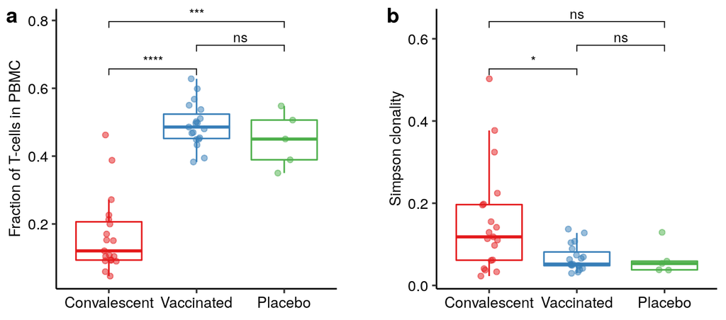

```r
# fig1 <- lymphopenia + shannon
fig1 <- ggarrange(lymphopenia, NULL, clonality, nrow = 1,
                  widths = c(1,0.1,1),
          labels = c("a", "", "b"))
fig1
```

```r
# ggexport(fig1, filename = "/media/bacon/covid-tcr/plots/fig1.pdf", width = 6.8, height = 3)
```

## 3.2 Breadth and depth of SARS-CoV-2-specific T cell response

### 3.2.1 Fig. 4a: Spike breadth and depth

Wilcoxon test:

```r
stat.test <- breadth_depth %>%
  left_join(repertoire_metadata, by = c("sample" = "Sample")) %>%
  select(c(Group, spike_breadth)) %>%
  wilcox_test(spike_breadth ~ Group, p.adjust.method = "none")
stat.test
```

```
## # A tibble: 3 x 9
##   .y.         group1     group2      n1    n2 statistic     p p.adj p.adj.signif
## * <chr>       <chr>      <chr>    <int> <int>     <dbl> <dbl> <dbl> <chr>
## 1 spike_brea… Convalesc… Placebo     19     5       79  0.024 0.024 *
## 2 spike_brea… Convalesc… Vaccina…    19    19      204. 0.507 0.507 ns
## 3 spike_brea… Placebo    Vaccina…     5    19       19  0.041 0.041 *
```

Plot:

```r
y_breaks <- c(log10(3*10^-4), log10(10^-4), log10(3*10^-5), log10(10^-5), log10(3*10^-6))
y_labs <- c("3e-04", "1e-04", "3e-05", "1e-05", "3e-06")
sb <- breadth_depth %>%
  left_join(repertoire_metadata, by = c("sample" = "Sample")) %>%
  mutate(Group = factor(Group, levels = c("Convalescent", "Vaccinated", "Placebo"))) %>%
  ggplot(aes(x=Group, y = log10(spike_breadth), color = Group)) +
  geom_boxplot(outlier.shape = NA) +
  geom_jitter(width = 0.1, alpha = 0.5, size = 1.5, aes(color = Group)) +
  scale_y_continuous(name = "Spike T-cell breadth", breaks = y_breaks, labels = y_labs) +
  scale_x_discrete(name = NULL) +
  scale_color_brewer(palette = "Set1") +
  stat_pvalue_manual(
  stat.test,
  y.position = -3.7, step.increase = 0.1,
  label = "p.adj.signif", size = 3.2
  ) +
  theme_pubr() +
  theme(axis.text = element_text(size = 10),
        axis.title = element_text(size = 10),
        legend.position = "none")
```

Median and IQR:

```r
breadth_depth %>%
  left_join(repertoire_metadata, by = c("sample" = "Sample")) %>%
  select(c(Group, spike_breadth)) %>%
  group_by(Group) %>%
  summarise(Median = median(spike_breadth),
            IQR = IQR(spike_breadth))
```

```
## # A tibble: 3 x 3
##   Group            Median       IQR
##   <chr>             <dbl>     <dbl>
## 1 Convalescent 0.00000664 0.0000140
## 2 Placebo      0          0
## 3 Vaccinated   0.00000545 0.0000110
```

Wilcoxon test:

```r
stat.test <- breadth_depth %>%
  left_join(repertoire_metadata, by = c("sample" = "Sample")) %>%
  select(c(Group, spike_depth)) %>%
  wilcox_test(spike_depth ~ Group, p.adjust.method = "none")
stat.test
```

```
## # A tibble: 3 x 9
##   .y.        group1     group2       n1    n2 statistic     p p.adj p.adj.signif
## * <chr>      <chr>      <chr>     <int> <int>     <dbl> <dbl> <dbl> <chr>
## 1 spike_dep… Convalesc… Placebo      19     5       79  0.024 0.024 *
## 2 spike_dep… Convalesc… Vaccinat…    19    19      176. 0.918 0.918 ns
## 3 spike_dep… Placebo    Vaccinat…     5    19       19  0.041 0.041 *
```

Plot:

```r
y_breaks <- c(log10(10^-1), log10(10^-2), log10(10^-3), log10(10^-4), log10(10^-5), log10(10^-6))
y_labs <- c("1e-01", "1e-02", "1e-03", "1e-04", "1e-05", "1e-06")
sd <- breadth_depth %>%
  left_join(repertoire_metadata, by = c("sample" = "Sample")) %>%
  mutate(Group = factor(Group, levels = c("Convalescent", "Vaccinated", "Placebo"))) %>%
  ggplot(aes(x=Group, y = log10(spike_depth), color = Group)) +
  geom_boxplot(outlier.shape = NA) +
  geom_jitter(width = 0.1, alpha = 0.5, size = 1.5, aes(color = Group)) +
  scale_y_continuous(name = "Spike T-cell depth", breaks = y_breaks, labels = y_labs) +
  scale_x_discrete(name = NULL) +
  scale_color_brewer(palette = "Set1") +
  stat_pvalue_manual(
    stat.test,
    y.position = -2, step.increase = 0.1,
    label = "p.adj.signif", size = 3.2
    ) +
  theme_pubr() +
  theme(axis.text = element_text(size = 10),
        axis.title = element_text(size = 10),
        legend.position = "none")
```

Median and IQR:

```r
breadth_depth %>%
  left_join(repertoire_metadata, by = c("sample" = "Sample")) %>%
  select(c(Group, spike_depth)) %>%
  group_by(Group) %>%
  summarise(Median = median(spike_depth),
            IQR = IQR(spike_depth))
```

```
## # A tibble: 3 x 3
##   Group            Median       IQR
##   <chr>             <dbl>     <dbl>
## 1 Convalescent 0.00000421 0.0000144
## 2 Placebo      0          0
## 3 Vaccinated   0.00000732 0.0000547
```

### 3.2.2 Fig. 4b: Non-spike breadth and depth

Wilcoxon test:

```r
stat.test <- breadth_depth %>%
  left_join(repertoire_metadata, by = c("sample" = "Sample")) %>%
  select(c(Group, non_spike_breadth)) %>%
  wilcox_test(non_spike_breadth ~ Group, p.adjust.method = "none")
stat.test
```

```
## # A tibble: 3 x 9
##   .y.       group1   group2      n1    n2 statistic       p   p.adj p.adj.signif
## * <chr>     <chr>    <chr>    <int> <int>     <dbl>   <dbl>   <dbl> <chr>
## 1 non_spik… Convale… Placebo     19     5       86  7.00e-3 7.00e-3 **
## 2 non_spik… Convale… Vaccina…    19    19      316. 8.60e-5 8.60e-5 ****
## 3 non_spik… Placebo  Vaccina…     5    19       39  5.69e-1 5.69e-1 ns
```

Plot:

```r
y_breaks <- c(log10(10^-3), log10(3*10^-4), log10(10^-4), log10(3*10^-5), log10(10^-5), log10(3*10^-6))
y_labs <- c("1e-03", "3e-04", "1e-04", "3e-05", "1e-05", "3e-06")
nsb <- breadth_depth %>%
  left_join(repertoire_metadata, by = c("sample" = "Sample")) %>%
  mutate(Group = factor(Group, levels = c("Convalescent", "Vaccinated", "Placebo"))) %>%
  ggplot(aes(x=Group, y = log10(non_spike_breadth), color = Group)) +
  geom_boxplot(outlier.shape = NA) +
  geom_jitter(width = 0.1, alpha = 0.5, size = 1.5, aes(color = Group)) +
  scale_y_continuous(name = "Non-spike T-cell breadth", breaks = y_breaks, labels = y_labs) +
  scale_x_discrete(name = NULL) +
  scale_color_brewer(palette = "Set1") +
  stat_pvalue_manual(
    stat.test,
    y.position = -3.2, step.increase = 0.1,
    label = "p.adj.signif",size = 3.2
    ) +
  theme_pubr() +
  theme(axis.text = element_text(size = 10),
        axis.title = element_text(size = 10),
        legend.position = "none")
```

Median and IQR:

```r
breadth_depth %>%
  left_join(repertoire_metadata, by = c("sample" = "Sample")) %>%
  select(c(Group, non_spike_breadth)) %>%
  group_by(Group) %>%
  summarise(Median = median(non_spike_breadth),
            IQR = IQR(non_spike_breadth))
```

```
## # A tibble: 3 x 3
##   Group            Median        IQR
##   <chr>             <dbl>      <dbl>
## 1 Convalescent 0.0000304  0.0000396
## 2 Placebo      0.00000940 0.0000124
## 3 Vaccinated   0.00000809 0.00000627
```

Wilcoxon test:

```r
stat.test <- breadth_depth %>%
  left_join(repertoire_metadata, by = c("sample" = "Sample")) %>%
  select(c(Group, non_spike_depth)) %>%
  wilcox_test(non_spike_depth ~ Group, p.adjust.method = "none")
stat.test
```

```
## # A tibble: 3 x 9
##   .y.         group1     group2      n1    n2 statistic     p p.adj p.adj.signif
## * <chr>       <chr>      <chr>    <int> <int>     <dbl> <dbl> <dbl> <chr>
## 1 non_spike_… Convalesc… Placebo     19     5       77  0.039 0.039 *
## 2 non_spike_… Convalesc… Vaccina…    19    19      284. 0.003 0.003 **
## 3 non_spike_… Placebo    Vaccina…     5    19       45  0.887 0.887 ns
```

Plot:

```r
y_breaks <- c(log10(10^-2), log10(10^-3), log10(10^-4), log10(10^-5))
y_labs <- c("1e-02", "1e-03", "1e-04", "1e-05")
nsd <- breadth_depth %>%
  left_join(repertoire_metadata, by = c("sample" = "Sample")) %>%
  mutate(Group = factor(Group, levels = c("Convalescent", "Vaccinated", "Placebo"))) %>%
  ggplot(aes(x=Group, y = log10(non_spike_depth), color = Group)) +
  geom_boxplot(outlier.shape = NA) +
  geom_jitter(width = 0.1, alpha = 0.5, size = 1.5, aes(color = Group)) +
  scale_y_continuous(name = "Non-spike T-cell depth", breaks = y_breaks, labels = y_labs) +
  scale_x_discrete(name = NULL) +
  scale_color_brewer(palette = "Set1") +
  stat_pvalue_manual(
    stat.test,
    y.position = -2.5, step.increase = 0.1,
    label = "p.adj.signif", size = 3.2
    ) +
  theme_pubr() +
  theme(axis.text = element_text(size = 10),
        axis.title = element_text(size = 10),
        legend.position = "none")
```

Median and IQR:

```r
breadth_depth %>%
  left_join(repertoire_metadata, by = c("sample" = "Sample")) %>%
  select(c(Group, non_spike_depth)) %>%
  group_by(Group) %>%
  summarise(Median = median(non_spike_depth),
            IQR = IQR(non_spike_depth))
```

```
## # A tibble: 3 x 3
##   Group            Median        IQR
##   <chr>             <dbl>      <dbl>
## 1 Convalescent 0.0000276  0.000115
## 2 Placebo      0.0000101  0.0000131
## 3 Vaccinated   0.00000732 0.00000682
```

Assemble figure:

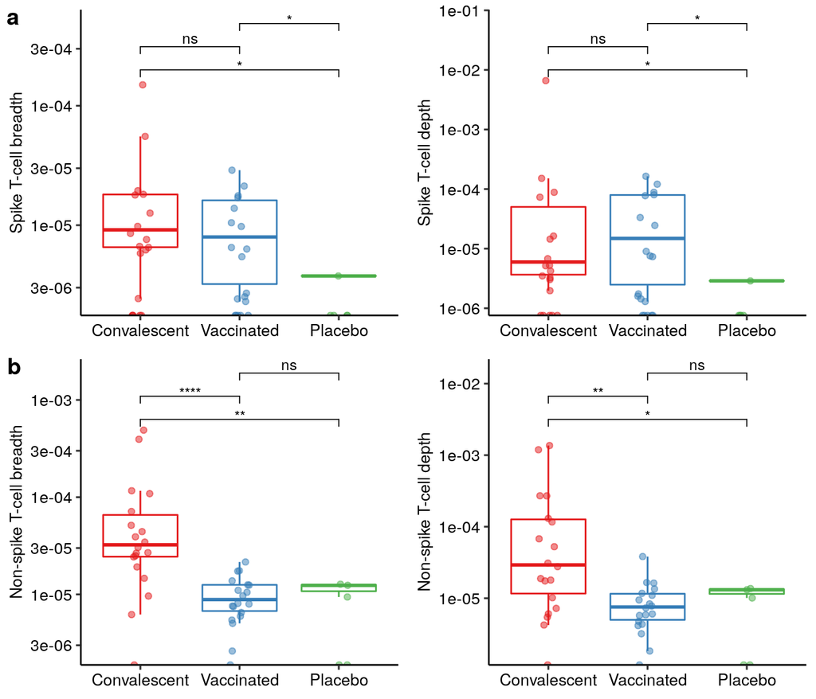

```r
figa <- ggarrange(sb, sd)
figb <- ggarrange(nsb, nsd)
bd <- ggarrange(figa, figb,
          labels = c("a", "b"),
          nrow = 2)
bd
```

```r
# ggexport(bd, filename = "/media/bacon/covid-tcr/plots/fig2.pdf",
#          width = 7,
#          height = 6)
```

### 3.2.3 Fig. 5a: TCR hits lollipop plot

```r
mean_pos <- function(a, b){
  a + ((b-a)/2)
}


hits.data <- metaclono_annotation %>%
  left_join(adaptive_metadata, by = c("Sample" = "sample_name")) %>%
  group_by(Sample, protein_coordinate) %>%
  summarise(breadth = n() / productive_rearrangements,
            depth = sum(templates) / productive_templates) %>%
  left_join(repertoire_metadata) %>%
  group_by(Group, protein_coordinate) %>%
  summarise(avg_breadth = mean(breadth),
            avg_depth = mean(depth)) %>%
  separate(protein_coordinate, into = c("prot", "coords"), sep = " ") %>%
  separate(coords, into = c("epitope_sindex", "epitope_eindex"), sep = ":") %>%
  mutate(epitope_sindex = as.numeric(epitope_sindex),
         epitope_eindex = as.numeric(epitope_eindex)) %>%
  mutate(epitope_size = epitope_eindex - epitope_sindex) %>%
  mutate(epitope_mean = (epitope_size / 2) + epitope_sindex) %>%
  filter(epitope_size <= 1000) %>% # Remove one long epitope (inespecific)
  mutate(Group = factor(Group, levels = rev(c("Convalescent", "Vaccinated", "Placebo")))) %>%
  mutate(Group = case_when(
    Group == "Placebo" ~ 1,
    Group == "Vaccinated" ~ 2,
    Group == "Convalescent" ~ 3,
  ))
covid_coords <- data.frame(start = c(266, 21555, 25384, 26220, 26472, 27191, 27387, 27759, 27887, 28259, 29533),
                           end = c(21555, 25384, 26220, 26472, 27191, 27387, 27759, 27887, 28259, 29533, 29674),
                           gene = c("ORF1ab", "S", "ORF3a", "E", "M", "ORF6", "ORF7a", "ORF7b", "ORF8", "N", "ORF10"),
                           y = c(rep(0.55, 11))) %>%
  mutate(gene = factor(gene, levels = c("ORF1ab", "S", "ORF3a", "E", "M", "ORF6", "ORF7a", "ORF7b", "ORF8", "N", "ORF10")))
```

Plot:

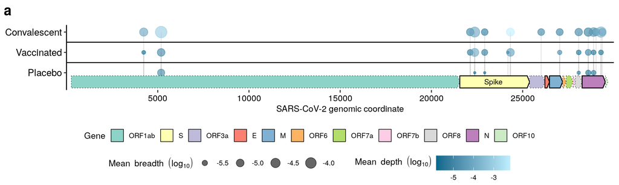

```r
lollipop <- ggplot() +
geom_segment(data = hits.data, aes(x=epitope_mean, xend=epitope_mean, y=0.5, yend=Group), alpha = 0.1) +
geom_point(data = hits.data, aes(x=epitope_mean, y = Group, size = log10(avg_breadth), color = log10(avg_depth)), alpha=0.6) +
geom_gene_arrow(data = covid_coords, mapping = aes(xmin = start, xmax = end, fill = gene, y = y),
  arrowhead_height = unit(5, "mm"), arrowhead_width = unit(1, "mm"), arrow_body_height = unit(5, "mm"),
  linetype = c("dotted", "solid", "dotted", "solid", "solid", "dotted", "dotted", "dotted", "dotted", "solid", "dotted"),
  size = c(0.2,0.5,0.2,0.5,0.5,0.2,0.2,0.2,0.2,0.5,0.2)) + #
  annotate(geom="text", x=23400, y=0.555, label="Spike", size = 3) +
  geom_hline(yintercept = 1.5) +
  geom_hline(yintercept = 2.5) +
scale_fill_brewer(palette = "Set3", name = "Gene") +
scale_x_continuous(expand = c(0,0), limits = c(0, 30000), breaks = c(5000, 10000, 15000, 20000, 25000), name = "SARS-CoV-2 genomic coordinate") +
scale_y_continuous(breaks = c(1,2,3), labels = c("Placebo", "Vaccinated", "Convalescent"), expand = c(.1,.1)) +
scale_color_gradient(low = "deepskyblue4", high = "lightblue1", name = expression(Mean~depth~(log["10"])), guide = "colorbar") +
  # scale_color_viridis_c(name = expression(Mean~depth~(log["10"]))) +
scale_size_continuous(name = expression(Mean~breadth~(log["10"]))) +
theme_pubr() +
guides(fill = guide_legend(order= 1,  nrow = 1, title.position = "left"),
       size = guide_legend(order = 2, title.position = "left"),
       color = guide_colorbar(order = 3, title.position = "left")) +
theme(legend.position = "bottom",
      legend.box = "vertical",
      legend.text=element_text(size = 8),
      legend.title = element_text(size = 10),
      axis.title.y = element_blank(),
      axis.line.x = element_blank(),
      axis.text.x = element_text(size = 10),
      axis.text.y = element_text(size = 11),
      axis.title.x = element_text(size = 10),
      legend.box.margin=margin(10,10,10,10))

plt <- lollipop +
  theme(legend.position = "none")

plt.fill <- lollipop +
  guides(size = FALSE,
       color = FALSE)
fill.leg <- get_legend(plt.fill)
fill.leg <- as_ggplot(fill.leg)

plt.size.col <- lollipop +
  guides(fill = FALSE,
         color = guide_colorbar(order = 3, title.position = "left", title.vjust = 1)) +
  theme(legend.position = "bottom",
      legend.box = "horizontal")
size.col.leg <- get_legend(plt.size.col)
size.col.leg <- as_ggplot(size.col.leg)

hits.plt <- ggarrange(NULL, plt, fill.leg, size.col.leg, labels = c("a", "", "", ""),
          ncol = 1, heights = c(0.3,1.5,0.5,0.5), font.label = list(size = 16))
hits.plt
```

## 3.3 TCR similarity network analysis

### 3.3.1 Fig. 6a: Convalescent and vaccinated networks

Plot:

```r
set.seed(123)
gc <- covid_networks$`860011445_TCRB`

V(gc)$antigen.protein[V(gc)$antigen.protein == ""] <- NA

layoutc <- layout.fruchterman.reingold(gc, niter=10000, area=50*vcount(gc)^2)
set.seed(123)
gv <- covid_networks$Vaccine_Subj12

V(gv)$antigen.protein[V(gv)$antigen.protein == ""] <- NA

layoutv <- layout.fruchterman.reingold(gv, niter=100, area=50*vcount(gv)^2, grid="nogrid")
```

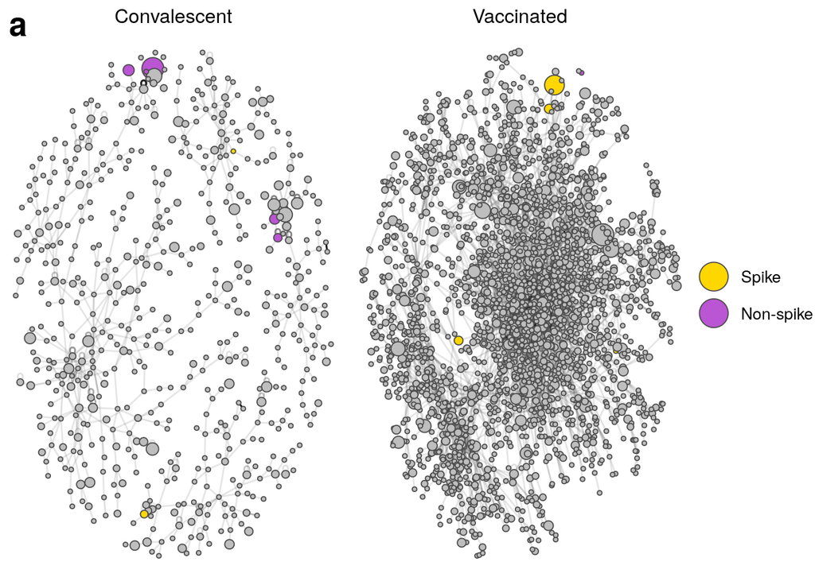

```r
pal = c("gold", "mediumorchid")

nw.leg <- ggraph(gc, layout = layoutc) +
  geom_node_point(aes(size=templates, fill = antigen.protein), alpha = 1, shape=21, color = "grey30") +
  scale_fill_manual(values = pal, na.value = "grey", breaks = c("Spike", "Non-spike")) +
  guides(alpha = FALSE,
         size = FALSE,
         fill = guide_legend(override.aes = list(size=8))) +
  theme(legend.text = element_text(size = 10),
        legend.title=element_blank(),
        legend.key=element_blank())

fill.leg <- get_legend(nw.leg)
fill.leg <- as_ggplot(fill.leg)

c18_nw <- ggraph(gc, layout = layoutc) + # stress
  geom_edge_link(aes(alpha = inv.distance)) +
  geom_edge_loop(aes(alpha = 0.1, direction = 90, span = 100, strength = 1.5), n = 1000) +
  geom_node_point(aes(size=templates, fill = antigen.protein), alpha = 1, shape=21, color = "grey30") +
  scale_fill_manual(values = pal, na.value = "grey", breaks = c("Spike", "Non-spike")) +
  scale_alpha(range = c(0.5,1)) +
  theme_void() +
  ggtitle("Convalescent") +
  theme(legend.position = "none",
        plot.title = element_text(hjust = 0.5, size = 12))


# c18_nw

v12_nw <- ggraph(gv, layout = layoutv) +
  geom_edge_link(aes(alpha = inv.distance)) +
  geom_edge_loop(aes(alpha = 0.1, direction = 90, span = 100, strength = 3.5), n = 1000) +
  geom_node_point(aes(size=templates, fill = antigen.protein), alpha = 1, shape=21, color = "grey30") +
  scale_fill_manual(values = pal, na.value = "grey", breaks = c("Spike", "Non-spike")) +
  theme_void() +
  ggtitle("Vaccinated") +
  theme(legend.position = "none",
        plot.title = element_text(hjust = 0.5, size = 12))

# v12_nw

two_nets <- ggarrange(c18_nw, v12_nw, fill.leg,
                      ncol = 3, widths = c(2,2,0.7),
                      labels = c("a", "", ""),
                      font.label = list(size = 20))
two_nets
```

### 3.3.2 Fig. 6b: Network global metrics

```r
# breadth_depth2 <- readRDS("/media/bacon/covid-tcr/analysis/03_add_convalescent_samples/breadth_depth_metaclono_hi_holm005_cdr3v_cd4_meta_target_NEW_11_convalescent.rds") %>% mutate(sample = paste0(sample, "_TCRB"))
#
# janssen_metadata <- read.table("/media/bacon/covid-tcr/data/janssen_vaccine/metadata.txt", sep = "\t", header = TRUE) %>% add_row(Sample = breadth_depth2$sample, Group = "Convalescent")
```

Nodes:

Wilcoxon test:

```r
stat.test <- covid_global_metrics %>%
  select(sample, nodes) %>%
  left_join(repertoire_metadata, by = c("sample" = "Sample")) %>%
  mutate(Group = as.character(Group)) %>%
  mutate(Group = case_when(
  is.na(Group) ~ "Convalescent",
  TRUE ~ Group)) %>%
    mutate(Group = factor(Group, levels = c("Convalescent", "Vaccinated", "Placebo"))) %>%
  wilcox_test(nodes ~ Group, p.adjust.method = "none")
stat.test
```

```
## # A tibble: 3 x 9
##   .y.   group1    group2      n1    n2 statistic         p    p.adj p.adj.signif
## * <chr> <chr>     <chr>    <int> <int>     <dbl>     <dbl>    <dbl> <chr>
## 1 nodes Convales… Vaccina…    19    19      25.5   6.44e-6  6.44e-6 ****
## 2 nodes Convales… Placebo     19     5      42     7.22e-1  7.22e-1 ns
## 3 nodes Vaccinat… Placebo     19     5      70     1.18e-1  1.18e-1 ns
```

Plot:

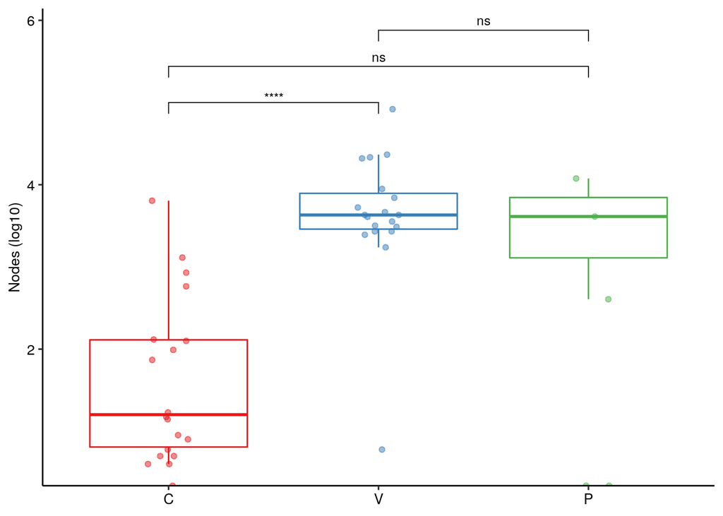

```r
# my_comparisons <- list( c("Convalescent", "Vaccinated"), c("Vaccinated", "Placebo"), c("Convalescent", "Placebo") )
nodes.plt <- covid_global_metrics %>%
  select(sample, nodes) %>%
  left_join(repertoire_metadata, by = c("sample" = "Sample")) %>%
  mutate(Group = as.character(Group)) %>%
  mutate(Group = case_when(
  is.na(Group) ~ "Convalescent",
  TRUE ~ Group)) %>%
    mutate(Group = factor(Group, levels = c("Convalescent", "Vaccinated", "Placebo"))) %>% #
  ggplot(aes(x=Group, y=log10(nodes), color = Group)) +
  geom_boxplot(outlier.shape = NA) +
  geom_jitter(width=0.1, alpha = 0.5) +
  scale_x_discrete(name = NULL, labels = c("C", "V", "P")) +
  scale_color_brewer(palette = "Set1") +
   stat_pvalue_manual(
  stat.test,
  y.position = 5, step.increase = 0.1,
  label = "p.adj.signif", size = 3.2
  ) +
  scale_y_continuous(name = "Nodes (log10)") +
  theme_pubr() +
    theme(axis.text = element_text(size = 10),
        axis.title = element_text(size = 10),
        legend.position = "none")

nodes.plt
```

Edges:

Wilcoxon test:

```r
stat.test <- covid_global_metrics %>%
  select(sample, edges) %>%
  left_join(repertoire_metadata, by = c("sample" = "Sample")) %>%
  mutate(Group = as.character(Group)) %>%
  mutate(Group = case_when(
  is.na(Group) ~ "Convalescent",
  TRUE ~ Group)) %>%
    mutate(Group = factor(Group, levels = c("Convalescent", "Vaccinated", "Placebo"))) %>%
  wilcox_test(edges ~ Group, p.adjust.method = "none")
stat.test
```

```
## # A tibble: 3 x 9
##   .y.   group1    group2      n1    n2 statistic         p    p.adj p.adj.signif
## * <chr> <chr>     <chr>    <int> <int>     <dbl>     <dbl>    <dbl> <chr>
## 1 edges Convales… Vaccina…    19    19        27   7.89e-6  7.89e-6 ****
## 2 edges Convales… Placebo     19     5        40   6.17e-1  6.17e-1 ns
## 3 edges Vaccinat… Placebo     19     5        71   1.02e-1  1.02e-1 ns
```

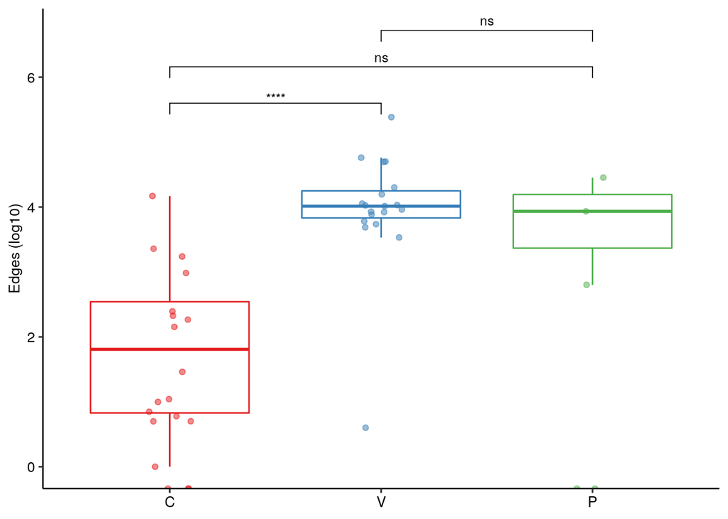

```r
edges.plt <- covid_global_metrics %>%
  select(sample, edges) %>%
  left_join(repertoire_metadata, by = c("sample" = "Sample")) %>%
  mutate(Group = as.character(Group)) %>%
  mutate(Group = case_when(
  is.na(Group) ~ "Convalescent",
  TRUE ~ Group)) %>%
    mutate(Group = factor(Group, levels = c("Convalescent", "Vaccinated", "Placebo"))) %>% #
  ggplot(aes(x=Group, y=log10(edges), color = Group)) +
  geom_boxplot(outlier.shape = NA) +
  geom_jitter(width=0.1, alpha = 0.5) +
  scale_x_discrete(name = NULL, labels = c("C", "V", "P")) +
  scale_color_brewer(palette = "Set1")  +
   stat_pvalue_manual(
  stat.test,
  y.position = 5.6, step.increase = 0.1,
  label = "p.adj.signif", size = 3.2
  ) +
  scale_y_continuous(name = "Edges (log10)") +
  theme_pubr() +
    theme(axis.text = element_text(size = 10),
        axis.title = element_text(size = 10),
        legend.position = "none")

edges.plt
```

Average degree:

Wilcoxon test:

```r
stat.test <- covid_global_metrics %>%
  select(sample, average_degree) %>%
  left_join(repertoire_metadata, by = c("sample" = "Sample")) %>%
  mutate(Group = as.character(Group)) %>%
  mutate(Group = case_when(
  is.na(Group) ~ "Convalescent",
  TRUE ~ Group)) %>%
    mutate(Group = factor(Group, levels = c("Convalescent", "Vaccinated", "Placebo"))) %>%
  wilcox_test(average_degree ~ Group, p.adjust.method = "none")
stat.test
```

```
## # A tibble: 3 x 9
##   .y.       group1    group2     n1    n2 statistic       p   p.adj p.adj.signif
## * <chr>     <chr>     <chr>   <int> <int>     <dbl>   <dbl>   <dbl> <chr>
## 1 average_… Convales… Vaccin…    19    19      52   2.17e-4 2.17e-4 ***
## 2 average_… Convales… Placebo    19     5      12.5 1.52e-1 1.52e-1 ns
## 3 average_… Vaccinat… Placebo    19     5      39.5 2.63e-1 2.63e-1 ns
```

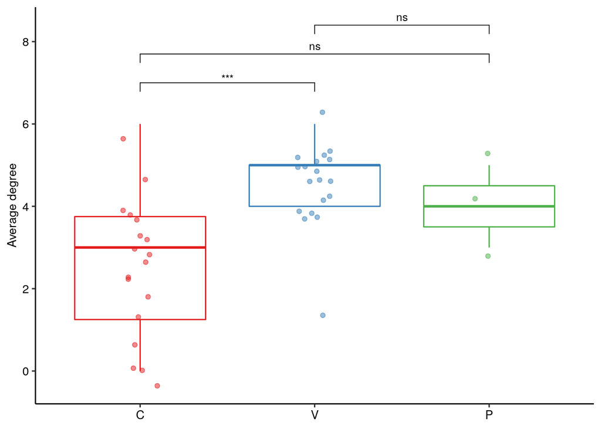

```r
average_degree.plt <- covid_global_metrics %>%
  select(sample, average_degree) %>%
  left_join(repertoire_metadata, by = c("sample" = "Sample")) %>%
  mutate(Group = as.character(Group)) %>%
  mutate(Group = case_when(
  is.na(Group) ~ "Convalescent",
  TRUE ~ Group)) %>%
    mutate(Group = factor(Group, levels = c("Convalescent", "Vaccinated", "Placebo"))) %>% #
  ggplot(aes(x=Group, y=average_degree, color = Group)) +
  geom_boxplot(outlier.shape = NA) +
  geom_jitter(width=0.1, alpha = 0.5) +
  scale_x_discrete(name = NULL, labels = c("C", "V", "P")) +
  scale_color_brewer(palette = "Set1")  +
   stat_pvalue_manual(
  stat.test,
  y.position = 7, step.increase = 0.1,
  label = "p.adj.signif", size = 3.2
  ) +
    scale_y_continuous(name = "Average degree") +
  theme_pubr() +
    theme(axis.text = element_text(size = 10),
        axis.title = element_text(size = 10),
        legend.position = "none")

average_degree.plt
```

Arrange figure:

```r
global.plt <- ggarrange(nodes.plt, edges.plt, average_degree.plt, ncol = 3, widths = c(1,1,1))
```

### 3.3.3 Fig. 6c: Hub scores

Plot:

```r
pal = c("gold", "mediumorchid")

stat.test <- covid_sns_local_metrics %>%
  select(Sample, antigen.protein, authority) %>%
  left_join(repertoire_metadata, by = "Sample") %>%
  mutate(Group = factor(Group, levels = c("Convalescent", "Vaccinated", "Placebo"))) %>%
  group_by(Group) %>%
  wilcox_test(authority ~ antigen.protein, p.adjust.method = "none") %>%
  add_significance("p")
stat.test
```

```
## # A tibble: 3 x 9
##   Group        .y.       group1 group2       n1    n2 statistic       p p.signif
##   <fct>        <chr>     <chr>  <chr>     <int> <int>     <dbl>   <dbl> <chr>
## 1 Convalescent authority Spike  Non-spike    25   117     1458  9.82e-1 ns
## 2 Vaccinated   authority Spike  Non-spike    43    82     2432. 2.37e-4 ***
## 3 Placebo      authority Spike  Non-spike     2    15       13  8.17e-1 ns
```

```r
stat.test <- stat.test %>%
  rstatix::add_xy_position(x = "Group", dodge = 0.8)
stat.test$antigen.protein <- NA
stat.test$y.position <- c(1,1,-7)
```

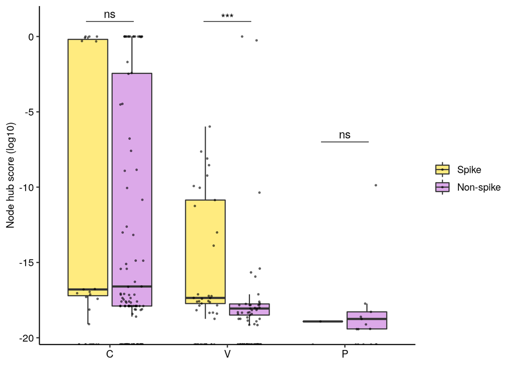

```r
auth.plt <- covid_sns_local_metrics %>%
  select(Sample, node_idx, templates, antigen.protein, authority) %>%
  left_join(repertoire_metadata, by = "Sample") %>%
  mutate(Group = factor(Group, levels = c("Convalescent", "Vaccinated", "Placebo"))) %>%
  ggplot(aes(x = Group, y = log10(authority), fill = antigen.protein)) +
  geom_boxplot(outlier.shape = NA, alpha = 0.5) +
  geom_jitter(alpha = 0.5, size = 0.5, position=position_jitterdodge()) +
  scale_fill_manual(values = pal, breaks = c("Spike", "Non-spike"), name = NULL) +
  scale_y_continuous(name = "Node hub score (log10)") +
  scale_x_discrete(name = NULL, labels = c("C", "V", "P")) +
  stat_pvalue_manual(stat.test, label = "p.signif", tip.length = 0) +
  theme_pubr() +
  theme(legend.position = "right",
        axis.text = element_text(size = 10),
        axis.title = element_text(size = 10))

auth.plt
```

Median and IQR:

```r
covid_sns_local_metrics %>%
  select(Sample, antigen.protein, authority) %>%
  left_join(repertoire_metadata, by = "Sample") %>%
  mutate(Group = factor(Group, levels = c("Convalescent", "Vaccinated", "Placebo"))) %>%
  group_by(Group, antigen.protein) %>%
  summarise(Median = median(authority),
            IQR = IQR(authority))
```

```
## # A tibble: 6 x 4
## # Groups:   Group [3]
##   Group        antigen.protein   Median      IQR
##   <fct>        <fct>              <dbl>    <dbl>
## 1 Convalescent Spike           3.84e-18 1.72e-17
## 2 Convalescent Non-spike       1.28e-18 9.76e-14
## 3 Vaccinated   Spike           1.87e-18 6.53e-15
## 4 Vaccinated   Non-spike       0.       6.34e-19
## 5 Placebo      Spike           6.05e-20 6.05e-20
## 6 Placebo      Non-spike       3.73e-20 2.12e-19
```

### 3.3.4 Fig. 6d: Histograms of node degree and self-loops

Degree spike:

```r
deg.s <- covid_sns_local_metrics %>%
  select(-c(betweenness, transitivity, pagerank, eigenvector_centrality, closeness)) %>%
  mutate(loops = case_when(
      is.na(loops) ~ 0,
      TRUE ~ loops
    ),
    deg_noloops = degree - loops) %>%
  select(-c(degree, authority)) %>%
  tidyr::uncount(templates) %>%
  filter(antigen.protein == "Spike") %>%
  left_join(repertoire_metadata, by = "Sample") %>%
  mutate(Group = factor(Group, levels = c("Convalescent", "Vaccinated", "Placebo"))) %>%
  ggplot(aes(x = deg_noloops, color = Group, fill = Group)) +
  geom_histogram(position="identity", alpha = 0.5, binwidth = 1) +
  scale_y_log10(expand = c(0,0), name = "Count") +
  scale_x_continuous(limits = c(0,25), breaks = seq(0,25,5), name = "Node degree") +
  scale_fill_brewer(palette = "Set1") +
  scale_color_brewer(palette = "Set1") +
  ggtitle("Spike nodes") +
  theme_pubr() +
    theme(legend.position = "none",
        axis.text = element_text(size = 10),
        axis.title = element_text(size = 10),
        plot.title = element_text(hjust = 0.5, size = 12))
```

Degree non-spike:

```r
deg.ns <- covid_sns_local_metrics %>%
  select(-c(betweenness, transitivity, pagerank, eigenvector_centrality, closeness)) %>%
  mutate(loops = case_when(
      is.na(loops) ~ 0,
      TRUE ~ loops
    ),
    deg_noloops = degree - loops) %>%
  select(-c(degree, authority)) %>%
  tidyr::uncount(templates) %>%
  filter(antigen.protein == "Non-spike") %>%
  left_join(repertoire_metadata, by = "Sample") %>%
  mutate(Group = factor(Group, levels = c("Convalescent", "Vaccinated", "Placebo"))) %>%
  ggplot(aes(x = deg_noloops, color = Group, fill = Group)) +
  geom_histogram(position="identity", alpha = 0.5, binwidth = 1) +
  scale_y_log10(expand = c(0,0), name = NULL) +
  scale_x_continuous(limits = c(0,25), breaks = seq(0,25,5), name = "Node degree") +
  scale_fill_brewer(palette = "Set1") +
  scale_color_brewer(palette = "Set1") +
  ggtitle("Non-spike nodes") +
  theme_pubr() +
    theme(legend.position = "none",
        axis.text = element_text(size = 10),
        axis.title = element_text(size = 10),
        plot.title = element_text(hjust = 0.5, size = 12))
```

Self-loops spike:

```r
loop.s <- covid_sns_local_metrics %>%
  select(-c(betweenness, transitivity, pagerank, eigenvector_centrality, closeness)) %>%
  mutate(loops = case_when(
      is.na(loops) ~ 0,
      TRUE ~ loops
    ),
    deg_noloops = degree - loops) %>%
  select(-c(degree, authority)) %>%
  tidyr::uncount(templates) %>%
  filter(antigen.protein == "Spike") %>%
  left_join(repertoire_metadata, by = "Sample") %>%
  mutate(Group = factor(Group, levels = c("Convalescent", "Vaccinated", "Placebo"))) %>%
  ggplot(aes(x = loops, color = Group, fill = Group)) +
  geom_histogram(position="identity", alpha = 0.5, binwidth = 1) +
  scale_y_log10(expand = c(0,0), name = "Count") +
  scale_x_continuous(limits = c(0,25), breaks = seq(0,25,5), name = "Self-loops") +
  scale_fill_brewer(palette = "Set1") +
  scale_color_brewer(palette = "Set1") +
  theme_pubr() +
    theme(legend.position = "none",
        axis.text = element_text(size = 10),
        axis.title = element_text(size = 10))
```

Self-loops non-spike:

```r
loop.ns <- covid_sns_local_metrics %>%
  select(-c(betweenness, transitivity, pagerank, eigenvector_centrality, closeness)) %>%
  mutate(loops = case_when(
      is.na(loops) ~ 0,
      TRUE ~ loops
    ),
    deg_noloops = degree - loops) %>%
  select(-c(degree, authority)) %>%
  tidyr::uncount(templates) %>%
  filter(antigen.protein == "Non-spike") %>%
  left_join(repertoire_metadata, by = "Sample") %>%
  mutate(Group = factor(Group, levels = c("Convalescent", "Vaccinated", "Placebo"))) %>%
  ggplot(aes(x = loops, color = Group, fill = Group)) +
  geom_histogram(position="identity", alpha = 0.5, binwidth = 1) +
  scale_y_log10(expand = c(0,0), name = NULL) +
  scale_x_continuous(limits = c(0,25), breaks = seq(0,25,5), name = "Self-loops") +
  scale_fill_brewer(palette = "Set1") +
  scale_color_brewer(palette = "Set1") +
  theme_pubr() +
    theme(legend.position = "none",
        axis.text = element_text(size = 10),
        axis.title = element_text(size = 10))
```

Assemble figure:

```r
hist.plt <- ggarrange(deg.s, deg.ns, loop.s, loop.ns, ncol = 2, nrow = 2, heights = c(1.1,1), widths = c(1.05,1))
hist.leg <- covid_sns_local_metrics %>%
  select(-c(betweenness, transitivity, pagerank, eigenvector_centrality, closeness)) %>%
  mutate(loops = case_when(
      is.na(loops) ~ 0,
      TRUE ~ loops
    ),
    deg_noloops = degree - loops) %>%
  select(-c(degree, authority)) %>%
  tidyr::uncount(templates) %>%
  filter(antigen.protein == "Non-spike") %>%
  left_join(repertoire_metadata, by = "Sample") %>%
  mutate(Group = factor(Group, levels = c("Convalescent", "Vaccinated", "Placebo"))) %>%
  ggplot(aes(x = loops, color = Group, fill = Group)) +
  geom_histogram(position="identity", alpha = 0.5, binwidth = 1) +
  scale_y_log10(expand = c(0,0), name = NULL) +
  scale_x_continuous(limits = c(0,25), breaks = seq(0,25,5), name = "Self-loops") +
  scale_fill_brewer(palette = "Set1", name = NULL) +
  scale_color_brewer(palette = "Set1", name = NULL) +
  theme_pubr()

fill.leg <- get_legend(hist.leg)
fill.leg <- as_ggplot(fill.leg)
```

```r
deg.loops.plt <- ggarrange(hist.plt, fill.leg, nrow = 2, heights = c(2, 0.2))
```

### 3.3.5 Fig. 6e: Biplot

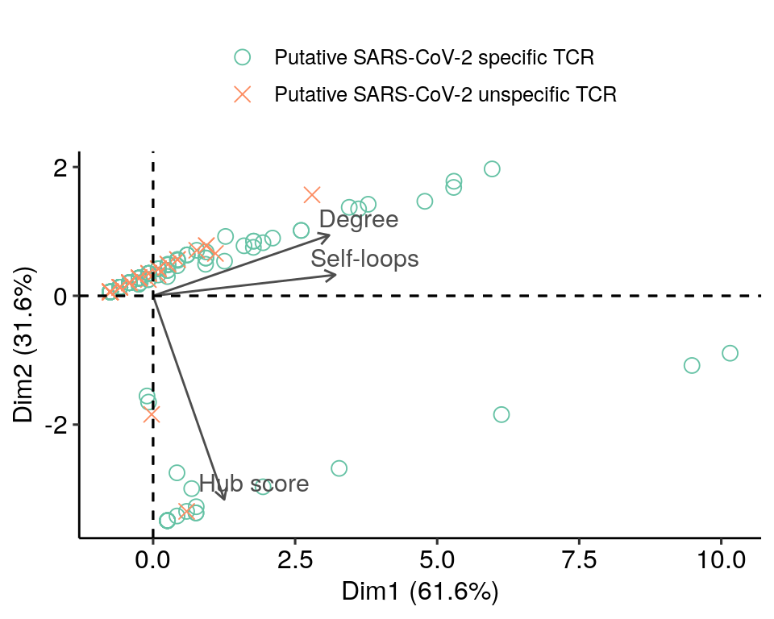

```r
x <- covid_sns_local_metrics %>%
  select(-c(betweenness, transitivity, pagerank, closeness, antigen.protein, eigenvector_centrality, templates)) %>%
  mutate(loops = case_when(
    is.na(loops) ~ 0,
    TRUE ~ loops
  ),
  deg_noloops = degree - loops) %>%
  select(-degree) %>%
  # left_join(all_covid_nodes, by = c("node_idx", "Sample")) %>%
  select(-c(Sample, node_idx)) %>%
  dplyr::rename("Degree" = deg_noloops,
                "Self-loops" = loops,
                "Hub score" = authority)

res.pca <- prcomp(x, scale = TRUE)

groups <- covid_sns_local_metrics %>%
  left_join(repertoire_metadata, by = "Sample") %>%
  mutate(is.ok = ifelse((Group=="Vaccinated" & antigen.protein == "Spike") | Group == "Convalescent", "Putative SARS-CoV-2 specific TCR", "Putative SARS-CoV-2 unspecific TCR" ),
         is.ok = factor(is.ok, levels = c("Putative SARS-CoV-2 specific TCR", "Putative SARS-CoV-2 unspecific TCR"))) %>%
  pull(is.ok)


pca.plt <- fviz_pca_biplot(res.pca, repel = TRUE,
                col.ind = groups,
                col.var = "gray30", # Variables color
                label = "var",
                invisible="quali",
                pointsize = 3) +
  scale_color_brewer(palette = "Set2", name = NULL) +
  scale_shape_manual(values = c(1,4), name = NULL) +
  theme_pubr() +
  ggtitle(NULL) +
  theme(legend.direction = "vertical",
        legend.position = "top")

pca.plt
```

Assemble Figure 6:

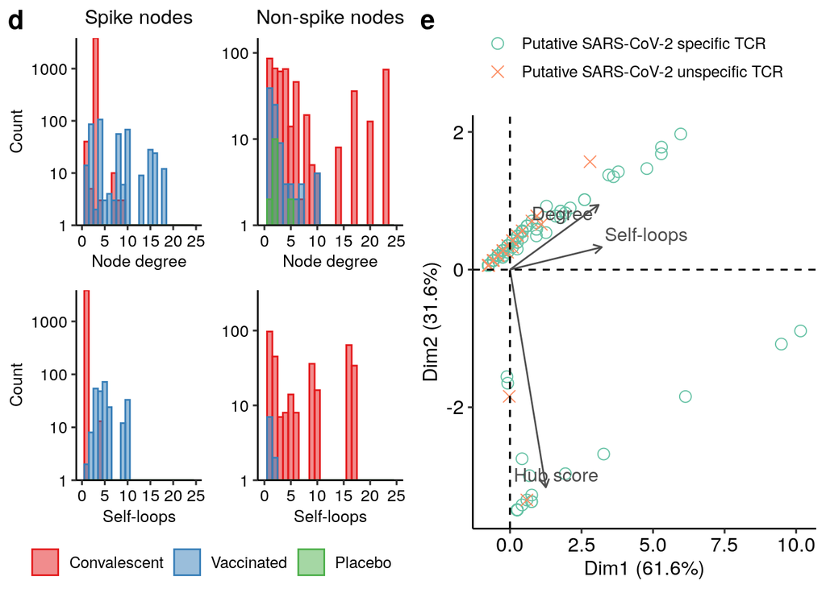

```r
middle.plt <- ggarrange(global.plt, NULL, auth.plt, nrow = 1,
          labels = c("b", "", "c"), widths = c(1.7, 0.05, 1),
          font.label = list(size = 16))
bottom.plt <- ggarrange(deg.loops.plt, pca.plt, ncol = 2, widths = c(2,2), labels = c("d", "e"), font.label = list(size = 16))
bottom.plt
```

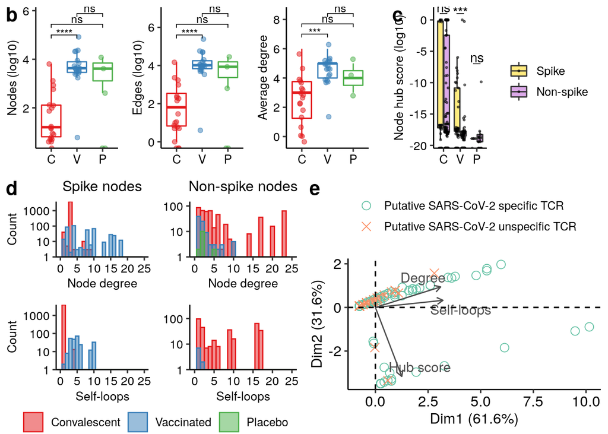

```r
full.fig <- ggarrange(middle.plt, bottom.plt, nrow = 2, heights = c(1,1.5))
full.fig
```